# Lista 1: Diagnóstico para pré-calculo

Thiago de Paula Oliveira

January 28, 2018

# Algebra

1. Avalie cada expressão sem utilizar uma calculadora

(a) $(-4)^2$ $\quad$ (b) $-4^2$ $\quad$ (c) $3^{-4}$ $\quad$ (d) $\frac{8^{15}}{8^{17}}$ $\quad$ (e) $\frac{7^{-15}}{7^{-18}}$ $\quad$ (f) $\left(\frac{2}{3}\right)^{-2}$ $\quad$ (g) $\left(\frac{4}{16}\right)^{-\frac{1}{2}}$ $\quad$ (h) $\left(\frac{36}{4}\right)^{\frac{1}{2}}$

2. Simplique cada expressão

(a) $(a+b)^2-(2a-b)^2$ $\quad$ (b) $(4a^3b)(c-a^{1/2})^2$ $\quad$ (c) $\left(\frac{x^3y^2}{x^2y^-2}\right)^{-2}$ $\quad$ (d) $\left(\frac{x^4+y^2}{x^2}\right)^{\frac{1}{2}}$ $\quad$ (f) $s^2+t-4st+(-2s+t)^2$ $\quad$

(g) $\frac{\sqrt{10}}{\sqrt{5}-2}$ $\quad$ (h) $\frac{\sqrt{4+h}-2}{h}$

3. Fatore cada expressão

(a) $4x^2-25$ $\quad$ (b) $x^2-2xy+y^2$ $\quad$ (c) $\frac{x^2+y^2-4xy}{x^3+y^2+2xy}$ $\quad$ (d) $x^4y^2-4x^2y$ $\quad$ (e) $\frac{ry+(ry)^2}{r^4+y^3-4ry}$ $\quad$ (f) $3x^{3/2}-9x^{1/2}+6x^{-1/2}$

(g) $\frac{\mbox{tg}(t)\left(x^2y^{2}-2xy\right)}{\mbox{tg}\left(xy\right)+y^2-x^2}$ $\quad$ (h) $\mbox{sen}^{2}(x)+\mbox{cos}^{2}(x)+3x$

4. Resolva a equação considerando apenas soluções reais

(a) $x+5=x-3$ $\quad$ (b) $2x^2-4x=15$ $\quad$ (c) $\frac{x+1}{x-1}=4$ $\quad$ (d) $\frac{x+1}{x^2+4x}=\frac{1}{x}$ $\quad$ (e) $|x+5|=4$ $\quad$ (f) $\sqrt{x+4}+5x=\sqrt{7}$

(g) $|x^2+2x|=12$ $\quad$ (h) $x^4+x^3+x^2=12x$

5. Resolva as inequações. Escreva as soluções utilizando a notação de intervalos.

(a) $7 \leq x+3 \leq 10$ $\quad$ (b) $1 \leq x^2+3^2 \leq 50$ $\quad$ (c) $(x+3)^2 \leq 15$ $\quad$ (d) $7 \leq \frac{x+2}{x+1} \leq 10$ $\quad$ (e) $5\leq \frac{x^2+2}{x} \leq 10$

# Geometria analítica

1. Encontre a equação da reta que passa através do ponto (1,-5) e tem coeficiente angular -5
2. Encontre a equação do círculo cujo centro está em (-2,2) e passa pelos pontos (4,3)
3. Ache o centro e o raio da circunferência cuja equação é $x^2+y^2-6(x+2y)-18=0$
4. Encontre a equação da reta que passa pelos pontos (-1,10) e (10,-5)
5. Faça o gráfico das equações/inequações a seguir sombreando a região delimitada entre elas e pelo plano $xy$

(a) $3 \leq y \leq 8$ $\quad$ (b) $y \geq 10$ e $x \leq4$ $\quad$ (c) $|y|>5$ e $|x|<10$ $\quad$ (d) $8x^{2}+5y^{2}=144$ $\quad$ (e) $x^2-y^2<10$

# Funções

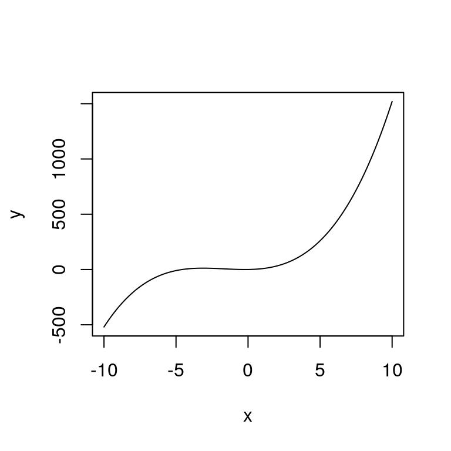

Figura para o exercício 1

```r
curve(x^3+5*x^2+2*x, from = -10, to=10, n=500, ylab = "y")
```

1. Responda a partir do gráfico de $f$ representado na Figura 1.
1. Estime $f(0)$.
2. Estime o valor de $f(-8)$ e de $f(10)$.
3. Estime $f(x)= 500$.
4. Defina o domínio e imagem da função $f$.
2. Considere a função $f(x)=x^4$, calcule $\frac{f(a+h)-f(a)}{a+h}$
3. Encontre o domínio das seguintes funções

(a) $f(x)=\frac{x+2}{x-1}$ $\quad$ (b) $f(x)=\frac{\sqrt{x}}{x^2+2x-1}$ $\quad$ (c) $f(x)=\log(x)+\sqrt{x}$ $\quad$ (d) $f(x)=\sqrt{x+2}+\sqrt{x^2+x}$

(e) $f(x)=\log{x^2}+\frac{3x}{x^2+2x}$

# Trigonometria

1. Converta de graus para radianos.

(a) $269^{\circ}$ $\quad$ (b) $-50^{\circ}$ $\quad$ (c) $180^{\circ}$ $\quad$ (d) $-18^{\circ}$ $\quad$

2. Converta de radianos para graus

(a) $\pi/2$ $\quad$ (b) $\frac{2\pi}{12}$ $\quad$ (c) $2$ $\quad$ (d) $2\pi$ $\quad$

3. Calcule os valores

(a) $\mbox{tg}(\pi/3)$ $\quad$ (b) $\mbox{sen}\left(\pi+2\right)$ $\quad$ (c) $\mbox{cos}(0)$ $\quad$ (d) $\mbox{cos}(\pi/4)$

4. Prove as identidades

(a) $\mbox{tg}\theta \mbox{ } \mbox{sen}\theta + \mbox{cos}\theta = \mbox{sec}\theta$ $\quad$ (b) $\mbox{sen}^2\theta+\mbox{cos}^2\theta =1$ $\quad$ (c) $\frac{2\mbox{tg }x}{1+\mbox{tg}^2x}=\mbox{sen}2x$